# Controlling invasive Argentine ants, Linepithema humile , in conservation areas using horizontal insecticide transfer | Scientific Reports

# Controlling invasive Argentine ants, *Linepithema humile*, in conservation areas using horizontal insecticide transfer

- Grzegorz Buczkowski &
- Theresa C. Wossler

[*Scientific Reports*](https://www.nature.com/srep) **volume 9**, Article number: 19495 (2019) Cite this article

## Abstract

Invasive ants are major agricultural and urban pests and a significant concern in conservation areas. Despite long history of control and eradication efforts, invasive ants continue to spread around the globe driven by a multitude of synergistic factors. Lack of effective management tools is one of the biggest challenges in controlling invasive ants. The goal of the current study was to improve the efficacy and safety of ant management and to develop effective control strategies for sensitive conservation areas. We utilized the Argentine ant (*Linepithema humile*) as a model system to evaluate a target-specific pesticide delivery system that exploits the interconnected nature of social insect colonies to distribute a toxicant effectively within the colony. The approach, based entirely on horizontal transfer, takes advantage of various levels of social interactions in ant colonies to disseminate a toxicant throughout the colony. Results of laboratory studies coupled with LC/MS/MS analysis demonstrate that fipronil is toxic to Argentine ants in extremely small (nanogram) quantities and is efficiently transferred from a single treated donor to multiple recipients, causing significant secondary mortality. A field study was conducted in native fynbos plots invaded by Argentine ants. The study consisted of collecting naïve workers, treating them with fipronil, and releasing them within invaded plots. Results show that the release of fipronil-treated ants reduced Argentine ant abundance by >90% within 24 h. The horizontal transfer approach offers environmental benefits with regard to pesticide use in ecologically sensitive environments and appears ideally suited for ant management in conservation areas.

## Introduction

Invasive ants continue to spread globally driven by multiple factors including globalization<sup>1,2</sup>, climate change<sup>3</sup>, secondary invasions<sup>4,5</sup>, lack of effective management tools<sup>6</sup>, poor understanding of biology and natural history<sup>7</sup>, and a variety of technical and political factors<sup>8</sup>. Among invasive ants, the Argentine ant, *Linepithema humile*, is one of the most widespread and damaging invaders<sup>9,10</sup>. This is due to its global distribution, high local abundance, and high potential to cause ecological and economic damage<sup>9,11,12</sup>. Argentine ants are mainly associated with anthropogenic environments and are frequently a pest in urban environments<sup>13</sup>. However, Argentine ants also invade native habitats with relatively little human disturbance<sup>14,15,16</sup>. In South Africa, Argentine ants have invaded the Cape Floral Region, one of the world’s most iconic centers of plant biodiversity<sup>17,18</sup>.

The effective management of invasive ants is constrained by a number of factors, many relating to their social and spatial structure<sup>8</sup>. A major issue is that many protocols for ant management are not truly based on ant biology<sup>19</sup> and the prevailing treatment strategies and product labels are not entirely compatible with the ant’s biology and unicolonial population structure<sup>8</sup>. Many species have high-density polygynous populations and colonies often nest in inaccessible places that are protected from direct pesticide applications. Furthermore, many ant species are highly polydomous, comprised of multiple, spatially dispersed nests further complicating efforts to find and effectively treat all nests. Locating nests prior to treatment is not practical in most situations, especially natural environments where terrain and ground cover limit access. Instead, the insecticide is typically applied in areas where ants are expected to nest and/or forage<sup>19,20</sup>. Foraging workers subsequently visit the treated areas and translocate the insecticide to other members of the colony, especially individuals that do not forage (queens) or cannot forage (larvae) independently. However, most spray insecticide treatments deployed for ant control result in only a small proportion of foraging workers being killed directly and control is often incomplete and resurgences are common<sup>21</sup>.

While the high-density and interconnected nature of Argentine ant supercolonies is a major impediment to their effective control, it may also offer opportunities for improving management approaches. The cohesion, efficiency, and survival of ant colonies is dependent on interaction networks and exchanges which require direct contract among individuals<sup>22</sup>. In situations where individuals are exposed to pesticides, direct contact among individuals may promote insecticide spread through horizontal transfer. Horizontal transfer occurs when foraging individuals acquire the insecticide at the point of application and subsequently transfer it to other members of the population<sup>23</sup> through various social behaviors, most notably allogrooming. Subsequently, horizontal transfer may result in secondary mortality if a lethal dose is transferred from exposed donors to unexposed recipients.

To improve the efficacy and safety of ant management more research is needed on new treatment products, delivery methods, and technologies. One of the most important goals is to develop effective ant control strategies for sensitive conservation areas. The main goal of such efforts is to minimize negative environmental impact, specifically pesticide residues that might have non-target effects. Recent developments in this area include hydrogel baits<sup>24,25,26</sup>, prey-baiting based on the use of insecticide-treated prey<sup>27,28</sup>, and pheromone-assisted baiting<sup>29,30</sup>. Another new development is exploiting social interactions within colonies to promote the spread of insecticides through horizontal transfer. A recent study evaluated a novel control method based on horizontal transfer for controlling black carpenter ants, *Camponotus pennsylvanicus*<sup>31</sup>. A three-step method consisting of trap-treat-release was used in field experiments and demonstrated that fipronil is effectively transferred when foraging workers are trapped, sprayed with insecticide, and released back into their colonies. Fipronil was effectively vectored from treated donor ants to untreated recipients and caused significant secondary mortality.

The goal of the current study was to build on work described in<sup>31</sup> and evaluate a target-specific pesticide delivery system that relies on horizontal transfer to control Argentine ants in South African fynbos. The first objective was to perform laboratory studies to generate quantitative information on factors affecting horizontal transfer, specifically the amount of fipronil transferred from treated to untreated ants and the number of untreated ants killed in interactions with a single treated ant. The second objective was to utilize information obtained in laboratory experiments to examine horizontal transfer in areas invaded by Argentine ants and to determine the feasibility of the horizontal transfer approach for practical pest control.

## Methods

### Horizontal transfer of fipronil – analytical study using LC/MS/MS

Colonies of Argentine ants, *Linepithema humile*, were collected in Winston-Salem, North Carolina and transported to the laboratory at Purdue University. Colonies were reared on 25% sucrose solution provided *ad libitum* and freshly killed cockroaches twice a week. Colonies were maintained and all experiments were conducted at 27 ± 2 °C, 60 ± 10% RH, and 14:10 L:D cycle. Experimental colonies were set up by aspirating 100 workers from stock colonies and transferring them to 25 × 30 × 9 cm high Fluon-coated plastic boxes. The ants were allowed 48 h to acclimate to an artificial nest consisting of a plastic Petri dish (5 cm diameter) filled with moist dental plaster. Food consisting of 15% sucrose water was provided during the acclimation period and during the test. At the end of the acclimation period, a single worker (donor) obtained from conspecific colonies was introduced into the recipient colony. To differentiate donors from recipients, the donors were marked with a small dot of acrylic paint (Testors Craft, Rust-Oleum Corp, Vernon Hills, IL) on the abdomen. The donors were sprayed with Termidor SC (9.1% fipronil, BASF Corporation, Research Triangle Park, NC). The spray solution was prepared by mixing 6.3 mL of Termidor with 1 liter of water resulting in 0.06% fipronil solution. The 0.06% concentration is the label rate recommended for controlling pest ants. To prepare the donors, 20 worker ants were placed inside a plastic Petri dish (9 cm diameter). The inner side of the dish was coated with Fluon to prevent escapes. The spray solution was delivered using an atomizer (Specialty Bottle, Seattle, WA). A single pump from the atomizer, equivalent 150 µL of 0.06% Termidor, was delivered to the dish so that all ants were uniformly coated with a thin layer of spray solution. To estimate the amount of fipronil present on the donors, 12 randomly selected ants were removed from the treatment dish, placed in individual glass tubes, and kept in −20 °C freezer until analysis. The remaining ants were transferred to nest boxes containing 100 recipient workers, one donor per recipient colony (n = 6). To estimate the amount of fipronil transferred from donors to recipients, 10 dead recipient ants were randomly selected from each of six replicates, 24 h after introducing the donors. For LC/MS/MS analysis, each recipient ant was placed into a 1.7 mL centrifuge tube and 0.1 mL of acetonitrile extraction solvent containing 300 ng/mL of <sup>13</sup>C<sub>4</sub>-fipronil (Sigma Aldrich, St. Louis, MO) was added to each ant. The ants were ground using plastic pestles, vortexed, and sonicated for 10 minutes, then centrifuged at 10,000 rpm × 5 minutes. The supernatant was collected and stored at −20 °C. The extracts were analyzed using LC/MS/MS at the Metabolite Profiling Facility at Bindley Bioscience Center at Purdue University. An Agilent 1200 Rapid Resolution liquid chromatography (LC) system coupled to an Agilent 6460 series QQQ mass spectrometer (MS) was used to analyze fipronil in each sample. An Agilent Zorbax SB-Phenyl 2.1 mm × 100 mm, 3.5 µm column was used for LC separation (Agilent Technologies, Santa Clara, CA). The buffers were: (a) water +0.1% formic acid and (b) acetonitrile +0.1% formic acid. The linear LC gradient was as follows: time 0 minutes, 10% B; time 0.5 minutes, 10% B; time 8 minutes, 100% B; time 10 minutes, 100% B; time 11 minutes, 10% B; time 15 minutes, 10% B. The flow rate was 0.3 mL/min. Multiple reaction monitoring was used for MS analysis. The jet stream ESI interface had a gas temperature of 325 °C, gas flow rate of 7 L/minute, nebulizer pressure of 45 psi, sheath gas temperature of 250 °C, sheath gas flow rate of 7 L/minute, capillary voltage of 3500 V in negative mode, and nozzle voltage of 500 V. The ΔEMV voltage was 400. All data were analyzed with Agilent Masshunter Quantitative Analysis (Version B.06.00). A linear calibration curve was prepared from 0.2–1500 ng/mL for fipronil and <sup>13</sup>C<sub>4</sub>-fipronil was used as internal standard and for absolute quantitation. The retention time of fipronil was 8.97 minutes. The 434.7 → 329.9 (fipronil)/438.7 → 333.9 m/z (<sup>13</sup>C<sub>4</sub>-fipronil) transition was used for quantitation purposes.

### Horizontal transfer of fipronil – laboratory study

The goal of the laboratory study was to determine the number of Argentine ants killed in interactions with a single treated donor ant. This was accomplished by placing a single treated donor in colonies of progressively larger size. Experimental colonies were set up by aspirating workers from stock colonies and transferring them to 25 × 30 × 9 cm high Fluon-coated plastic boxes. Three colony sizes were tested: 100, 250, and 500 workers and six replicates were performed for each colony size. The ants were allowed 48 h to acclimate to an artificial nest consisting of a glass test tube (25 mm diameter × 150 mm long) half filled with water. The test tube was stoppered with a cork that contained a single hole to allow entry and wrapped in aluminum foil to keep it dark. Food consisting of 25% sucrose solution was provided during the acclimation period and during the test. At the end of the acclimation period, a single donor worker obtained from a conspecific colony was introduced into the recipient colony. To differentiate donors from recipients, the donors were marked with a small dot of acrylic paint on the abdomen as above. Donor ants were then treated with fipronil (0.06% Termidor SC) using direct spray as above and immediately transferred to nest boxes containing the recipients. Control tests (n = 6) consisted of colonies of 100, 250 or 500 workers provided with a single ant sprayed with water alone. Mortality in the donor and the recipients was determined at 2, 4, 8, 16, 24, 48, 72, and 96 hours.

### Targeted fipronil delivery – field study

Field plots containing colonies of *L. humile* were established at Helderberg Nature Reserve, Somerset West, Western Cape, South Africa (−34.06S, 018.87E). The plots were 10 by 10 m and were separated by at least 25 m buffer zones. To estimate initial ant densities (day 0) the plots were sampled using note cards baited with a blend of canned tuna and corn syrup<sup>32</sup>. Within each plot, the bait cards were placed along two transects, 10 m long perpendicular lines forming a cross through the center of each plot. Eight evenly spaced cards were used along each transect (16 baits per plot). The cards were placed on the ground and collected 1 hr after placement to estimate the number of Argentine ants present. Following census baiting, each 100 m<sup>2</sup> plot was provisioned with 10,000 treated donor ants (equivalent to 5.0 grams of workers) which had been topically sprayed with 0.06% fipronil. The number of donor ants selected was based on results obtained in LC/MS/MS analysis and laboratory transfer tests. Donor ants were collected within Helderberg Nature Reserve in areas outside of experimental plots, extracted from nesting material, placed in a plastic box, and sprayed using an atomizer. Each pump from the atomizer delivers 150 µL of spray solution (±5%). Ten pumps from the atomizer were delivered for each box so all the ants were uniformly coated with a thin layer of the spray solution. Therefore, a total of 1.5 mL of fipronil solution was applied to each box. This is equivalent to 1 gallon solution per 1,000 square feet (40 mL per sq m), the recommended application rate for Termidor. Following treatment, the ants were immediately released into the center of the experimental plot by gently emptying the container onto the ground and allowing them to naturally disperse. Efficacy of fipronil transfer was examined on days 1, 3, 7, 14, and 21 using baited note cards as above. Six experimental plots and four control plots were established. All assessments were performed from February to March 2019.

### Statistical analysis

The effect of colony size and time since exposure to fipronil treated nestmates on worker mortality in the laboratory was assessed using an ANOVA test. A two-way Repeated Measures ANOVA was used to assess the change in worker abundance over time under field conditions. The Greenhouse-Geisser correction was applied due to violations of the assumption of sphericity (Mauchly’s test) and equality of variances (Levene’s test). This test recalculates new degrees of freedom in order to obtain a valid *F-ratio*. Tukey’s HSD test was used for posthoc pairwise comparisons and parameter estimates showed changes in worker abundances relative to the reference group. Statistical significance was set at α = 0.05 and all analyses were performed using Statistica 13.2<sup>33</sup>.

## Results

### Horizontal transfer of fipronil – analytical study using LC/MS/MS

Results of the laboratory study on the horizontal transfer of fipronil coupled with LC/MS/MS analysis revealed that fipronil was efficiently transferred from treated donors to untreated recipients. The mean amount of fipronil detected on the donors was 78 ± 17 ng (range 39–94 ng; Fig. 1). The mean amount of fipronil detected on the recipients was 0.49 ± 0.79 ng (range 0.02–4.67 ng; Fig. 1). As expected, the mean amount of fipronil present on the donors was significantly higher than the amount present on the recipients (t-test, *t* = 34.9, *df* = 70, *P* < 0.001). The amount of fipronil detected on the recipients was highly consistent and less than one nanogram was detected on 53 out of 60 (88%) recipient ants (Fig. 1). The other recipients had fipronil levels ranging from 1 to less than 5 ng. Results demonstrate that fipronil applied via spray applications was readily transferred from treated to untreated workers and that fipronil is toxic to Argentine ants in extremely small amounts.

**Figure 1**

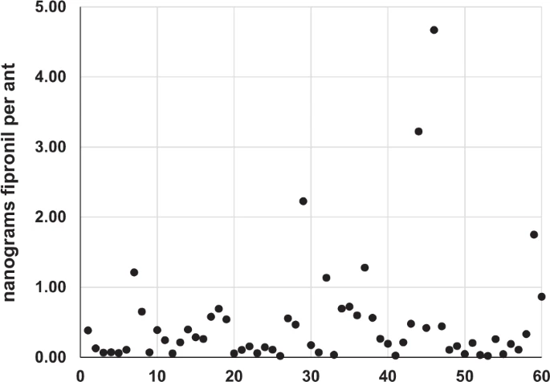

Nanograms of fipronil detected in recipient ants in tests where 100 untreated recipients interacted with a single treated donor. Each dot represents a single ant. Results for all 60 recipients are presented (6 replicates of 10 randomly selected recipients) in sets of 10 from left to right.

[Full size image](https://www.nature.com/articles/s41598-019-56189-1/figures/1)

### Targeted fipronil delivery – field study

**Figure 2**

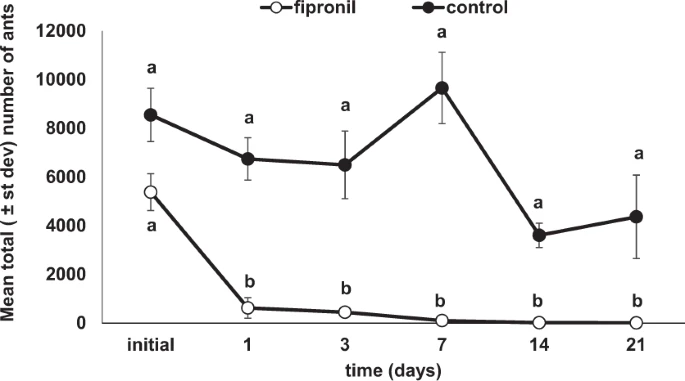

Mean total (±st dev) number of *L. humile* workers detected within field plots provisioned with fipronil-treated or water-treated (control) nestmates. Letters indicate pairwise differences in ant abundance at each assessment time between fipronil-treated and control plots.

[Full size image](https://www.nature.com/articles/s41598-019-56189-1/figures/2)

## Discussion

The current study evaluated a novel approach for controlling invasive ants, based solely on horizontal transfer. The approach takes advantage of various levels of social interactions in ant colonies to effectively distribute a toxicant within the colony and ultimately cause colony demise.

In summary, the current study evaluated a novel, target-specific approach for controlling invasive ants based on the principles of horizontal transfer. Future studies should aim to further optimize the transfer approach. One option might be to use treated brood instead of treated workers to vector toxicant throughout the population. Brood is extremely important for ant colonies and modulates a number of processes on both the individual and the colony level<sup>37</sup>. Ants are highly protective of their brood and exposed brood is immediately moved to the safety of the nest. Releasing treated brood might assure that the toxicant is placed where it’s likely going to be the most effective – below ground and in close proximity to the queens which might help target the reproductive caste and prevent resurgences. Another option might be to release treated workers from a mutually-aggressive supercolony to ensure more ant-to-ant contact. In the current study, horizontal transfer was achieved through peaceful behaviors such as mutual grooming and trophallaxis. However, the efficiency of transfer might increase if the toxicant is vectored via aggressive, rather than peaceful interactions. Argentine ants are highly aggressive towards non-nestmates from distinct supercolonies<sup>38,39</sup> and multiple workers typically cooperate in fighting a single non-nestmate which might accelerate the spread of the toxicant.

## References

1. 1.

   Roura-Pascual, N. *et al*. Relative roles of climatic suitability and anthropogenic influence in determining the pattern of spread in a global invader. *Proc Natl Acad Sci USA* **108**, 220–225 (2011).

   [ADS](http://adsabs.harvard.edu/cgi-bin/nph-data_query?link_type=ABSTRACT&bibcode=2011PNAS..108..220R) [CAS](https://www.nature.com/articles/cas-redirect/1%3ACAS%3A528%3ADC%252BC3MXms1KisA%253D%253D) [Article](https://doi.org/10.1073%2Fpnas.1011723108) Google Scholar
2. 2.

   Bertelsmeier, C., Ollier, S., Liebhold, A. & Keller, L. Recent human history governs global ant invasion dynamics. *Nature Ecol Evol* **22**, 25–42 (2017).

   Google Scholar
3. 3.

   Bertelsmeier, C., Blight, O. & Courchamp, F. Invasions of ants (Hymenoptera: Formicidae) in the light of global climate change. *Myr News* **22**, 25–42 (2016).

   Google Scholar
4. 4.

   Ascunce, M. S. *et al*. Global invasion history of the fire ant, *Solenopsis invicta*. *Science* **331**, 1066–1068 (2011).

   [ADS](http://adsabs.harvard.edu/cgi-bin/nph-data_query?link_type=ABSTRACT&bibcode=2011Sci...331.1066A) [CAS](https://www.nature.com/articles/cas-redirect/1%3ACAS%3A528%3ADC%252BC3MXit1eitr8%253D) [Article](https://doi.org/10.1126%2Fscience.1198734) Google Scholar
5. 5.

   Bertelsmeier, C. *et al*. Recurrent bridgehead effects accelerate global alien ant spread. *Proc Natl Acad Sci USA* **115**, 5486–5491 (2018).

   [CAS](https://www.nature.com/articles/cas-redirect/1%3ACAS%3A528%3ADC%252BC1cXitlWrtbfM) [Article](https://doi.org/10.1073%2Fpnas.1801990115) Google Scholar
6. 6.

   Hoffmann, B. D., Abbott, K. L. & David, P. Invasive ant management. In, *Ant Ecology*, *Oxford, UK**:* *Oxford University Press*, pp. 261–286 (2010).
7. 7.

   Hoffmann, B. D., Luque, G. M., Bellard, C., Holmes, N. D. & Donlan, C. J. Improving invasive ant eradication as a conservation tool: A review. *Biol Conserv* **198**, 37–49 (2016).

   [Article](https://doi.org/10.1016%2Fj.biocon.2016.03.036) Google Scholar
8. 8.

   Silverman, J. & Brightwell, R. J. The Argentine ant: challenges in managing an unicolonial invasive pest. *Ann Rev Entomol* **53**, 231–252 (2008).

   [CAS](https://www.nature.com/articles/cas-redirect/1%3ACAS%3A528%3ADC%252BD1cXht12js70%253D) [Article](https://doi.org/10.1146%2Fannurev.ento.53.103106.093450) Google Scholar
9. 9.

   Holway, D. A., Lach, L., Suarez, A. V., Tsutsui, N. D. & Case, T. J. Causes and consequences of ant invasions. *Ann Rev Ecol Evol Syst* **33**, 181–233 (2002).

   [Article](https://doi.org/10.1146%2Fannurev.ecolsys.33.010802.150444) Google Scholar
10. 10.

    Ward, D. F., Beggs, J. R., Clout, M. N., Harris, R. J. & O’Connor, S. The diversity and origin of exotic ants arriving in New Zealand via human-mediated dispersal. *Diversity Distrib* **12**, 601–609 (2006).

    [Article](https://doi.org/10.1111%2Fj.1366-9516.2006.00270.x) Google Scholar
11. 11.

    Suarez, A. V., Holway, D. A. & Case, T. J. Patterns of spread in biological invasions dominated by long-distance jump dispersal: insights from Argentine ants. *Proc Natl Acad Sci USA* **98**, 1095–1100 (2001).

    [ADS](http://adsabs.harvard.edu/cgi-bin/nph-data_query?link_type=ABSTRACT&bibcode=2001PNAS...98.1095S) [CAS](https://www.nature.com/articles/cas-redirect/1%3ACAS%3A528%3ADC%252BD3MXht1Smsbs%253D) [Article](https://doi.org/10.1073%2Fpnas.98.3.1095) Google Scholar
12. 12.

    Roura-Pascual, N. *et al*. Geographical potential of Argentine ants (*Linepithema humile* Mayr) in the face of global climate change. *Proc Royal Soc London B* **271**, 2527–2534 (2004).

    [Article](https://doi.org/10.1098%2Frspb.2004.2898) Google Scholar
13. 13.

    Rust, M. K. & Knight, R. L. Controlling Argentine ants in urban situations, In, *Applied myrmecology: a world perspective. Westview, Boulder, CO*, pp. 664–670 (1990).
14. 14.

    Holway, D. A. Effect of Argentine ant invasions on ground-dwelling arthropods in northern California riparian woodlands. *Oecologia* **116**, 252–258 (1998).

    [ADS](http://adsabs.harvard.edu/cgi-bin/nph-data_query?link_type=ABSTRACT&bibcode=1998Oecol.116..252H) [Article](https://doi.org/10.1007%2Fs004420050586) Google Scholar
15. 15.

    Cole, F. R., Medeiros, A. C., Loope, L. L. & Zuehlke, W. W. Effects of the Argentine ant on arthropod fauna of Hawaiian high-elevation shrubland. *Ecology* **73**, 1313–1322 (1992).

    [Article](https://doi.org/10.2307%2F1940678) Google Scholar
16. 16.

    Ward, D. F. & Harris, R. J. Invasibility of native habitats by Argentine ants, *Linepithema humile*, in New Zealand. New Zealand. *J Ecol* **29**, 215–219 (2005).

    Google Scholar
17. 17.

    Lach, L. A comparison of floral resource exploitation by native and invasive Argentine ants. *Arthropod Plant Interact* **7**, 177–190 (2013).

    [Article](https://doi.org/10.1007%2Fs11829-012-9231-2) Google Scholar
18. 18.

    Mothapo, P. N. & Wossler, T. C. Patterns of floral resource use by two dominant ant species in a biodiversity hotspot. *Biol Inv* **19**, 955–969 (2017).

    [Article](https://doi.org/10.1007%2Fs10530-016-1336-6) Google Scholar
19. 19.

    Hoffmann, B. *et al*. Improving ant eradications: details of more successes, a global synthesis, and recommendations. *Aliens* **31**, 16–23 (2011).

    Google Scholar
20. 20.

    Scharf, M. E., Ratliff, C. R. & Bennett, G. W. Impacts of residual insecticide barriers on perimeter-invading ants, with particular reference to the odorous house ant, *Tapinoma sessile*. *J Econ Entomol* **97**, 601–605 (2004).

    [CAS](https://www.nature.com/articles/cas-redirect/1%3ACAS%3A528%3ADC%252BD2cXktFOgtL0%253D) [Article](https://doi.org/10.1603%2F0022-0493-97.2.601) Google Scholar
21. 21.

    Rust, M. K., Soeprono, A. M. & Reierson, D. A. Horizontal transfer of barrier insecticides in Argentine ants (Hymenoptera: Formicidae). In, *Proceedings of the Fifth International Conference on Urban Pests. P&Y Design Network, Malaysia*, pp. 664–670 (2005).
22. 22.

    Hölldobler, B. & Wilson E. O. *The Ants*. *The Belknap Press of Harvard University Press, Cambridge, Massachusetts*. 732 pp (1990).
23. 23.

    Soeprono, A. M. & Rust, M. K. Effect of horizontal transfer of barrier insecticides to control Argentine ants (Hymenoptera: Formicidae). *J Econ Entomol* **97**, 1675–1681 (2004).

    [CAS](https://www.nature.com/articles/cas-redirect/1%3ACAS%3A528%3ADC%252BD2cXpvFansbY%253D) [Article](https://doi.org/10.1603%2F0022-0493-97.5.1675) Google Scholar
24. 24.

    Buczkowski, G., Roper, E., Chin, D., Mothapo, N. & Wossler, T. Hydrogel baits with low-dose thiamethoxam for sustainable Argentine ant management in commercial orchards. *Entomol Exp Applicata* **153**, 183–190 (2014).

    [CAS](https://www.nature.com/articles/cas-redirect/1%3ACAS%3A528%3ADC%252BC2cXitVektLzK) [Article](https://doi.org/10.1111%2Feea.12239) Google Scholar
25. 25.

    Buczkowski, G., Roper, E. & Chin, D. Polyacrylamide hydrogels: an effective tool for delivering liquid baits to pest ants. *J Econ Entomol* **107**, 748–757 (2014).

    [CAS](https://www.nature.com/articles/cas-redirect/1%3ACAS%3A528%3ADC%252BC2cXosVylsbg%253D) [Article](https://doi.org/10.1603%2FEC13508) Google Scholar
26. 26.

    Tay, J. W., Hoddle, M. S., Mulchandani, A. & Choe, D. H. Development of an alginate hydrogel to deliver aqueous bait for pest ant management. *Pest Manag Sci* **73**, 2028–2038 (2017).

    [CAS](https://www.nature.com/articles/cas-redirect/1%3ACAS%3A528%3ADC%252BC2sXht1WqsbjO) [Article](https://doi.org/10.1002%2Fps.4616) Google Scholar
27. 27.

    Buczkowski, G. The Trojan horse approach for managing invasive ants: a study with Asian needle ants, *Pachycondyla chinensis*. *Biol Inv* **18**, 507–515 (2016).

    [Article](https://doi.org/10.1007%2Fs10530-015-1023-z) Google Scholar
28. 28.

    Buczkowski, G., Mothapo, N. P. & Wossler, T. C. Let them eat termites – prey-baiting provides effective control of Argentine ant, *Linepithema humile*, in a biodiversity hotspot. *J Appl Entomol* **142**, 504–512 (2018).

    [CAS](https://www.nature.com/articles/cas-redirect/1%3ACAS%3A528%3ADC%252BC1cXps1KmurY%253D) [Article](https://doi.org/10.1111%2Fjen.12501) Google Scholar
29. 29.

    Sunamura, E. *et al*. Combined use of a synthetic trail pheromone and insecticidal bait provides effective control of an invasive ant. *Pest Manag Sci* **67**, 1230–1236 (2011).

    [CAS](https://www.nature.com/articles/cas-redirect/1%3ACAS%3A528%3ADC%252BC3MXhtFWqtbvE) [Article](https://doi.org/10.1002%2Fps.2172) Google Scholar
30. 30.

    Welzel, K. F. & Choe, D. H. Development of a pheromone-assisted baiting technique for Argentine ants (Hymenoptera: Formicidae). *J Econ Entomol* **109**, 1303–1309 (2016).

    [CAS](https://www.nature.com/articles/cas-redirect/1%3ACAS%3A528%3ADC%252BC1cXit1Wmt73O) [Article](https://doi.org/10.1093%2Fjee%2Ftow015) Google Scholar
31. 31.

    Buczkowski, G. Trap-treat-release: horizontal transfer of fipronil in field colonies of black carpenter ants, *Camponotus pennsylvanicus*. *Pest Manag Sci* **75**, 2195–2201 (2019).

    [CAS](https://www.nature.com/articles/cas-redirect/1%3ACAS%3A528%3ADC%252BC1MXjslOkur0%253D) [Article](https://doi.org/10.1002%2Fps.5345) Google Scholar
32. 32.

    Buczkowski, G. & Krushelnycky, P. The odorous house ant, *Tapinoma sessile* (Hymenoptera: Formicidae), as a new temperate-origin invader. *Myr News* **16**, 61–66 (2012).

    Google Scholar
33. 33.

    Statistica. StatSoft, Inc. Tulsa, OK, Version 13.2 (2017).
34. 34.

    Burford, B. P. *et al*. Foraging behavior and locomotion of the invasive Argentine ant from winter aggregations. *PLoS One* **13**(8), e0202117 (2018).

    [Article](https://doi.org/10.1371%2Fjournal.pone.0202117) Google Scholar
35. 35.

    Moffett, M. W. Supercolonies of billions in an invasive ant: what is a society? *Behav Ecol* **23**, 925–933 (2012).

    [Article](https://doi.org/10.1093%2Fbeheco%2Fars043) Google Scholar
36. 36.

    Pimentel, D. Amounts of pesticides reaching target pests: environmental impacts and ethics. *J Agric Environ Ethics* **100**, 495–508 (2007).

    Google Scholar
37. 37.

    Schultner, E., Oettler, J. & Helantera, H. The role of brood in eusocial Hymenoptera. *Quarterly Rev Biol* **92**, 39–78 (2017).

    [Article](https://doi.org/10.1086%2F690840) Google Scholar
38. 38.

    Buczkowski, G., Vargo, E. L. & Silverman, J. The diminutive supercolony: Argentine ants of the southeastern United States. *Mol Ecol News* **13**, 2235–2242 (2004).

    [CAS](https://www.nature.com/articles/cas-redirect/1%3ACAS%3A528%3ADC%252BD2cXmsl2rur4%253D) [Article](https://doi.org/10.1111%2Fj.1365-294X.2004.02261.x) Google Scholar
39. 39.

    Mothapo, P. N. & Wossler, T. C. Behavioural and chemical evidence for multiple colonization of the Argentine ant, *Linepithema humile*, in the Western Cape, South Africa. *BMC Ecology* **11**, 6 (2011).

    [Article](https://doi.org/10.1186%2F1472-6785-11-6) Google Scholar

[Download references](https://www.nature.com/articles/s41598-019-56189-1-references.ris)

## Acknowledgements

We thank N. Mothapo for assistance with ant collecting, M. Woodruff for rearing laboratory colonies, D. Richmond for advice on data analysis, and A. Jannasch for assistance with LC/MS/MS analysis. Permission to conduct research in Helderberg Nature Reserve was granted by Western Cape Nature Conservation Board (permit number AAA-007-00188-0056). We thank O. Wittridge, Biodiversity Coordinator at HNR, for facilitating work at the study site. Financial support was provided in part by the Center for Urban and Industrial Pest Management and the Industrial Affiliates Program at Purdue University.

## Author information

### Affiliations

1. Department of Entomology, Purdue University, West Lafayette, IN, 47907, USA

   Grzegorz Buczkowski
2. Department of Botany and Zoology, Stellenbosch University, Private Bag X1, Matieland, 7602, South Africa

   Theresa C. Wossler

### Contributions

G.B. designed the research, G.B and T.W. conducted the research, G.B. analyzed the data, G.B. and T.W. wrote and revised the manuscript.

### Corresponding author

Correspondence to [Grzegorz Buczkowski](https://www.nature.com/articles/s41598-019-56189-1/email/correspondent/c1/new).

## Ethics declarations

### Competing interests

The authors declare no competing interests.

## Additional information

**Publisher’s note** Springer Nature remains neutral with regard to jurisdictional claims in published maps and institutional affiliations.

## Rights and permissions

**Open Access** This article is licensed under a Creative Commons Attribution 4.0 International License, which permits use, sharing, adaptation, distribution and reproduction in any medium or format, as long as you give appropriate credit to the original author(s) and the source, provide a link to the Creative Commons license, and indicate if changes were made. The images or other third party material in this article are included in the article’s Creative Commons license, unless indicated otherwise in a credit line to the material. If material is not included in the article’s Creative Commons license and your intended use is not permitted by statutory regulation or exceeds the permitted use, you will need to obtain permission directly from the copyright holder. To view a copy of this license, visit http://creativecommons.org/licenses/by/4.0/.

Reprints and Permissions

## About this article

### Cite this article

Buczkowski, G., Wossler, T.C. Controlling invasive Argentine ants, *Linepithema humile*, in conservation areas using horizontal insecticide transfer. *Sci Rep* **9,** 19495 (2019). https://doi.org/10.1038/s41598-019-56189-1

[Download citation](https://www.nature.com/articles/s41598-019-56189-1.ris)

- Received: 29 July 2019
- Accepted: 04 December 2019
- Published: 20 December 2019
- DOI: https://doi.org/10.1038/s41598-019-56189-1

### Share this article

Anyone you share the following link with will be able to read this content:

Provided by the Springer Nature SharedIt content-sharing initiative

### Subjects

- [Conservation biology](https://www.nature.com/subjects/conservation)
- [Invasive species](https://www.nature.com/subjects/invasive-species)

## Comments

[Download PDF](https://www.nature.com/articles/s41598-019-56189-1.pdf)